# Analyse Géopolitique & Économique — USA, Israël & Iran

Analyse temporelle, militaire, pétrolière et apprentissage automatique (1948–2024)

Fatma Ayadi & Arij Khemiri

17 mai 2026

🎓 TEK-UP UNIVERSITY📊 Méthodes Statistiques & Étude de Données🗓 Année 2024–2025

Encadrant : Pr. Ahmed Dhouibi

Analyse Géopolitique & Économique  
USA · Israël · Iran

Analyse temporelle, militaire, pétrolière et apprentissage automatique (1948–2024)

Auteurs

Fatma Ayadi

Arij Khemiri

Pays analysés

Iran · Israel · USA

Période

1948 – 2024

77 années de données

Dataset

data_clean.csv

231 obs. · 12 variables

Soumission

17 mai 2026

# 1 Introduction

## 1.1 Contexte géopolitique et économique

Depuis 1948, le triangle géopolitique formé par les **États-Unis**, **Israël** et l’**Iran** constitue l’un des foyers les plus persistants d’instabilité régionale et mondiale. Ce rapport adopte une approche quantitative systématique pour répondre à une question fondamentale : **dans quelle mesure l’intensité conflictuelle se traduit-elle en données économiques mesurables ?**

🎯 Problématique centrale

Comment les tensions géopolitiques entre les USA, Israël et l’Iran influencent-elles les prix du pétrole, l’inflation et les grands équilibres macroéconomiques — et les méthodes statistiques permettent-elles d’en modéliser les effets ?

## 1.2 Questions de recherche

L’analyse est structurée autour de **cinq axes** :

1. Les tensions géopolitiques génèrent-elles des hausses mesurables du prix du Brent ?
2. Les dépenses militaires évoluent-elles différemment selon le pays et la période de conflit ?
3. Quels événements majeurs ont eu le plus d’impact sur les indicateurs macroéconomiques ?
4. Quelles variables sont les plus prédictives de la période géopolitique ?
5. Les algorithmes non supervisés retrouvent-ils les phases historiques sans connaissance a priori ?

## 1.3 Organisation du rapport

Le rapport progresse en **douze modules** : exploration temporelle → comparaison pays → analyse militaire → pétrole & inflation → événements historiques → corrélations → périodes de conflit → régressions → classification Random Forest → ACP → K-means → CAH.

# 2 Présentation des Données

## 2.1 Sources et construction du dataset

Le dataset `data_clean.csv` a été constitué par croisement de plusieurs bases de données institutionnelles pour trois pays (USA, Israël, Iran) sur la période 1948–2024.

Vue d’ensemble du dataset

| Dimension | Valeur |
| --- | --- |
| Observations | 231 lignes |
| Variables | 12 colonnes |
| Période couverte | 1948 – 2024 (77 ans) |
| Pays inclus | Iran · Israel · USA |
| Source principale | Banque Mondiale · SIPRI · EIA · UCDP · IISS |

## 2.2 Statistiques descriptives

Statistiques descriptives — principales variables numériques

| Variable | Min | Moyenne | Médiane | Max | Éc.-type |
| --- | --- | --- | --- | --- | --- |
| Military Expenditure Billion USD | 5.000000e-01 | 7.530000e+01 | 6.000000e+00 | 3.184000e+02 | 1.150000e+02 |
| Active Personnel | 1.406980e+05 | 7.838687e+05 | 4.435010e+05 | 3.000000e+06 | 7.009658e+05 |
| Conflict Severity Index | 0.000000e+00 | 1.900000e+00 | 2.000000e+00 | 5.000000e+00 | 1.900000e+00 |
| GDP current USD | 1.406678e+11 | 2.503832e+11 | 2.338051e+11 | 3.890339e+11 | 6.471805e+10 |
| GDP Growth Percent | -3.700000e+00 | 2.500000e+00 | 2.800000e+00 | 8.900000e+00 | 2.700000e+00 |
| Brent Oil Price USD per barrel | 1.900000e+01 | 1.053000e+02 | 1.003000e+02 | 1.883000e+02 | 4.580000e+01 |
| Inflation Rate Percent | 1.000000e-01 | 7.700000e+00 | 6.500000e+00 | 2.050000e+01 | 5.700000e+00 |
| Unemployment total pct | 4.400000e+00 | 8.900000e+00 | 9.900000e+00 | 1.380000e+01 | 2.600000e+00 |

# 3 Analyse Temporelle (1948–2024)

Module 1 · Analyse Temporelle

## 3.1 Croissance du PIB par pays

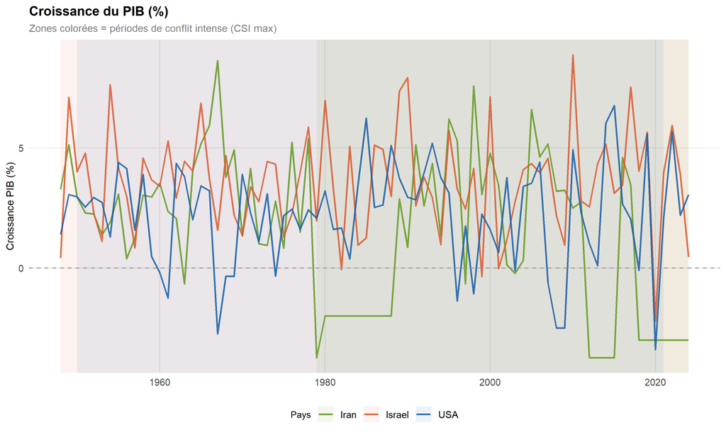

Croissance du PIB (%) de 1948 à 2024. Les zones colorées délimitent les périodes de conflit intense par pays. Les contractions de croissance sont visibles lors de chaque grande crise géopolitique.

## 3.2 Indice de conflit dans le temps

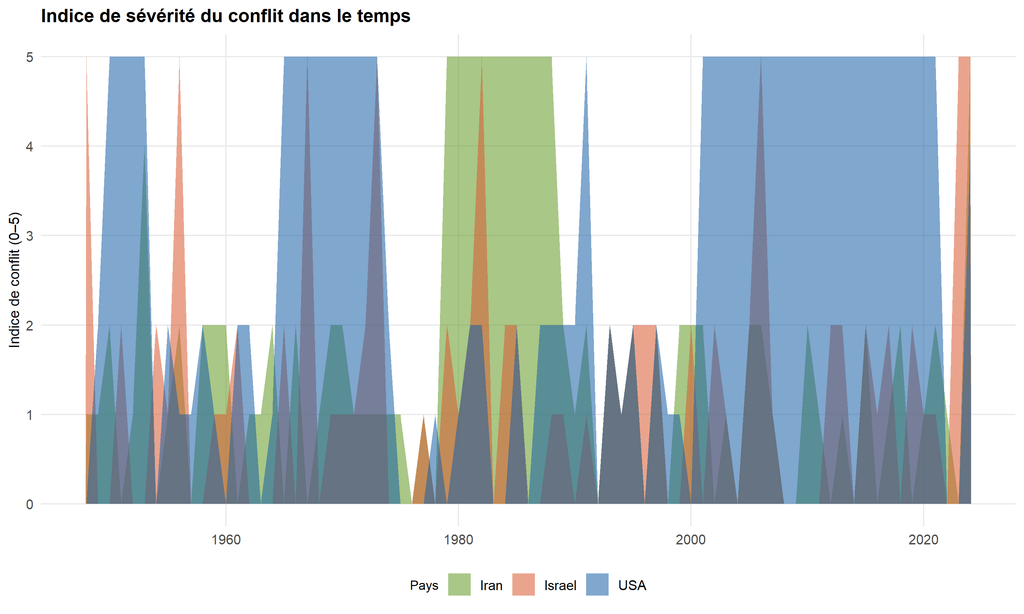

Indice de sévérité du conflit par pays (0–5). Les pics correspondent aux grandes crises régionales : guerre Iran-Irak (1980–88), Guerre du Golfe (1991), post-11 septembre (2001–2003), escalade récente (2019–2024).

## 3.3 Inflation comparée

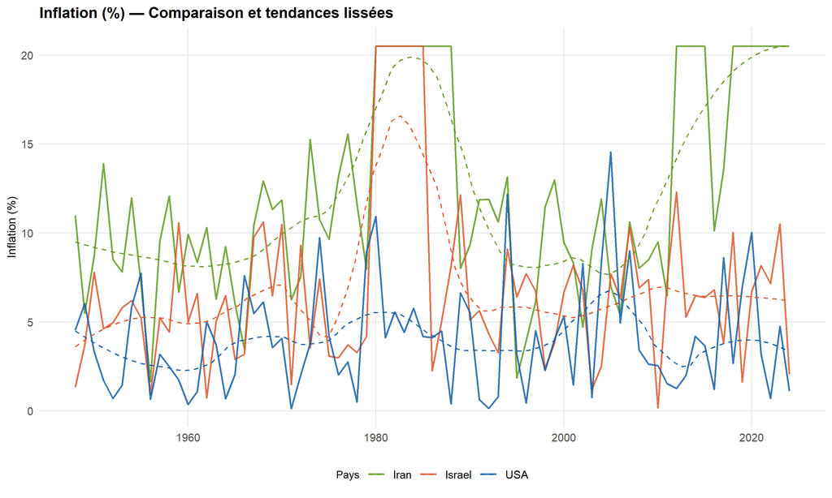

Taux d’inflation (%) avec courbe lissée LOESS. L’Iran se distingue par des épisodes hyperinflationnistes exceptionnels liés aux sanctions (2012–2018) et à la guerre Iran-Irak (1980–1988).

# 4 Comparaison Pays & Clustering

Module 2 · Comparaison Pays & K-means (k=4)

## 4.1 Distribution des variables clés par pays

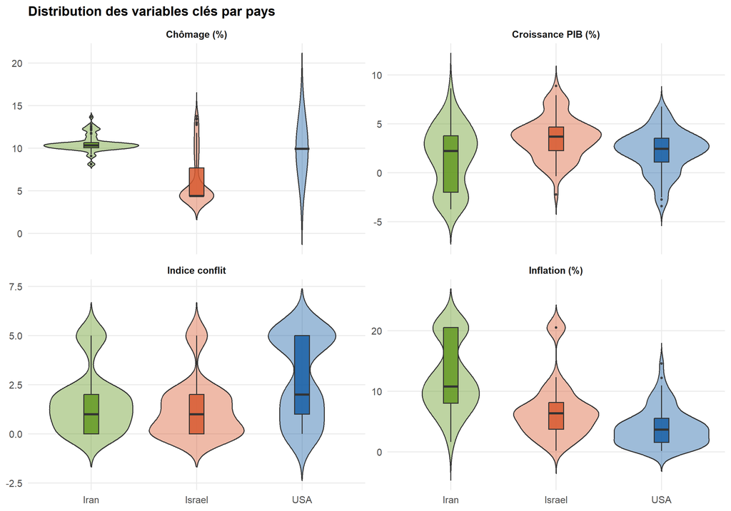

## 4.2 K-means (k=4) — Profils annuels

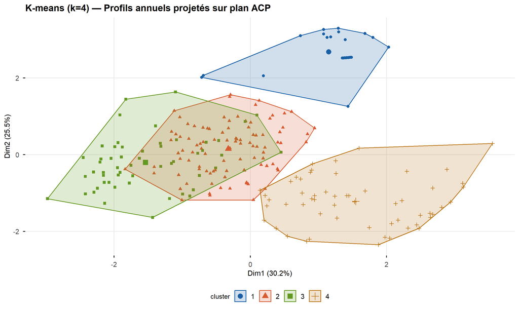

K-means (k=4) sur les données annuelles standardisées. Les quatre clusters révèlent des profils économiques et géopolitiques distincts selon les pays et les périodes historiques.